# Part II - Prosper Loan Data

## by Edgar Palacios

## Investigation Overview

> The goal of this presentation is to show the genral relationships between variables and defaulted loans along with elucidating unexpected trends that were found. While most loans that were granted were completed (69%) an interesting observation was made showing that loan holders who defaulted and had higher credit scores also had significantly elevated DTI ratios. This was unexpected considering that DTI vs Loan status visualization showed all mean DTI ratios below 40% for all loan status categories. This indicates that the model used to grant loans may be allowing much higher DTI ratios for applicants with higher credit scores than their low credit score counterparts.

## Dataset Overview

> The dataset explored here is from Propser. It contains 113,937 loans and 81 attributes including loan information and personal financial information.

## Distribution of Loan Statuses

> This visualization shows the distribution of the top-four loan status categories by counts. Top-four categories include 'Completed', 'Charged-off', 'Defaulted' and 'Cancelled' from most counts to least - respectively.

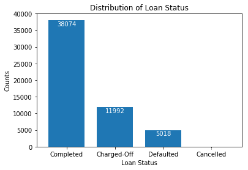

## Trends in Credit Grades per Loan Status

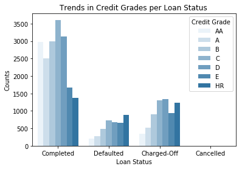

# Mean Values of DTI Ratios

> This visualization shows the mean values and confidence intervales of DTI ratio for each loan status category. Both defaulted and charged-off loans showed debt-to-income ratios above 30% while completed loans were below ~26%.

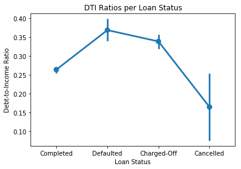

# Trends in DTI Ratio for Credit Grades and Loan Status

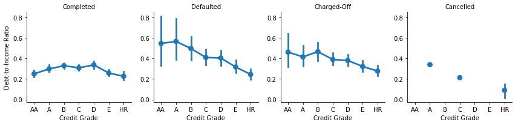

# Trends in Available Bank Credit

> The following visualization shows mean and confidence values for available bank credit for each credit grade in each loan status category. As credit grades increase, available bank card credit increases non-linearly.

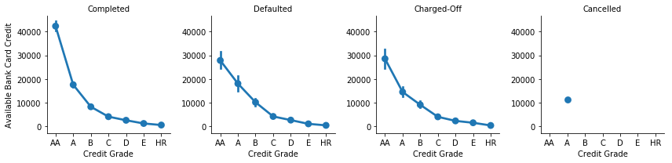